# Applying Augur to PBMC data

P. Nicol

8/5/2020

**Summary** In this file I apply Augur to the PBMC dataset. You’ll need to have Augur installed (do this from GitHub) to run this code.

## Load the data

As always, we load the data

```r
Sco <- readRDS("/Users/phillipnicol/Desktop/local_files/data/scDiffPopDATA/gse145281/seurat.RDS")
Sco <- subset(Sco, idents = c(15, 16), invert = TRUE)
```

We need to adjust the metadata so that Augur will accept it.

```r
cell_types <- c("Naive CD4+ T", "CD36+ Monocytes", "CXCR4+ NK", "CD68- Monocytes", "CD8A T", "CD14- INFG- Monocytes", "B cells", "CXCR4- NK", "Non classical monocytes", "Monocytes", "RUNX3+ NK", "Myeloid DC", "Low-density basophils", "Effector Memory T", "Th1")
response <- c("NR", "R")

Sco@meta.data <- data.frame(label = Sco$response, cell_type = as.integer(Sco$seurat_clusters))
Sco@meta.data[,1] <- sapply(Sco@meta.data[,1], function(x) response[x+1])
Sco@meta.data[,2] <- sapply(Sco@meta.data[,2], function(x) cell_types[x])

head(Sco@meta.data)
```

```
##                label         cell_type
## R1_HITS1432301     R Effector Memory T
## R1_HITS1432302     R        Myeloid DC
## R1_HITS1432303     R Effector Memory T
## R1_HITS1432304     R Effector Memory T
## R1_HITS1432305     R        Myeloid DC
## R1_HITS1432306     R   CD36+ Monocytes
```

Now we can run the Augur algorithm with default parameters

```r
augur = Augur::calculate_auc(Sco, n_threads = 8)

save(augur, file = "/Users/phillipnicol/Desktop/local_files/data/scDiffPopDATA/Augur/augur_res.RData")
```

The above chunk takes around 20 minutes to complete on my laptop.

## Results

Let’s take a look at what we got. First, we load the list from our files.

```r
load("/Users/phillipnicol/Desktop/local_files/data/scDiffPopDATA/Augur/augur_res.RData")
```

Now we take a look at the AUC

```r
augur$AUC
```

```
## # A tibble: 14 x 2
##    cell_type                 auc
##    <chr>                   <dbl>
##  1 CD8A T                  0.655
##  2 CD14- INFG- Monocytes   0.650
##  3 Myeloid DC              0.627
##  4 CD36+ Monocytes         0.612
##  5 B cells                 0.612
##  6 CD68- Monocytes         0.601
##  7 Naive CD4+ T            0.597
##  8 Non classical monocytes 0.596
##  9 Effector Memory T       0.590
## 10 Monocytes               0.586
## 11 CXCR4+ NK               0.569
## 12 CXCR4- NK               0.566
## 13 Th1                     0.556
## 14 RUNX3+ NK               0.539
```

Note that the algorithm cut out low-density basophils, since there are only 14 responding cells which have this cell type and the default settings of their algorithm requires at least $20$ cells in each class (maybe this is interesting). Let’s also plot it

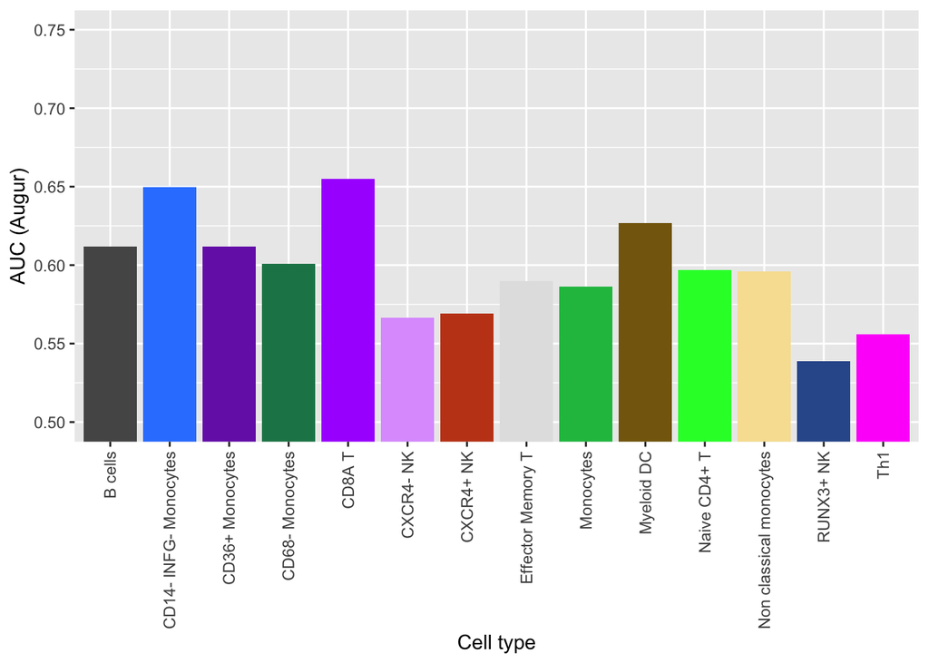

```r
library(ggplot2)

#prepare colors
library(Polychrome)
alfa <- alphabet.colors(14)

#plot
df <- as.data.frame(augur$AUC)
p <- ggplot(data=df, aes(x=cell_type, y = auc)) + geom_bar(stat = "identity", fill = alfa)
p <- p + xlab("Cell type") + ylab("AUC (Augur)") + coord_cartesian(ylim=c(0.5,0.75))
p <- p + theme(axis.text.x=element_text(angle=90,hjust=1,vjust=0.5))
plot(p)
```

```r
#save the plot
#png(file = "/Users/phillipnicol/Desktop/local_files/data/scDiffPopDATA/Augur/auc_pbmc.png")
```

## Randomization tests

We want to see if `Augur` can fit random noise (this would be a bad thing if it can).

First, we randomly shuffle all of the cell labels

```r
perm <- sample(1:nrow(Sco@meta.data), nrow(Sco@meta.data), replace = FALSE)
Sco@meta.data$label <- Sco@meta.data$label[perm]

head(Sco@meta.data)
```

```
##                label         cell_type
## R1_HITS1432301    NR Effector Memory T
## R1_HITS1432302    NR        Myeloid DC
## R1_HITS1432303     R Effector Memory T
## R1_HITS1432304     R Effector Memory T
## R1_HITS1432305    NR        Myeloid DC
## R1_HITS1432306     R   CD36+ Monocytes
```

Now all of the labels are scrambled, let’s see what Augur says

```r
augur_rand1 = Augur::calculate_auc(Sco, n_threads = 8)

save(augur_rand1, file = "/Users/phillipnicol/Desktop/local_files/data/scDiffPopDATA/Augur/augur_rand1_res.RData")
```

Now we take a look at the AUC

```r
load("/Users/phillipnicol/Desktop/local_files/data/scDiffPopDATA/Augur/augur_rand1_res.RData")
augur_rand1$AUC
```

```
## # A tibble: 15 x 2
##    cell_type                 auc
##    <chr>                   <dbl>
##  1 CD14- INFG- Monocytes   0.521
##  2 CXCR4+ NK               0.519
##  3 RUNX3+ NK               0.510
##  4 Th1                     0.505
##  5 CXCR4- NK               0.505
##  6 CD8A T                  0.504
##  7 CD36+ Monocytes         0.503
##  8 Naive CD4+ T            0.503
##  9 CD68- Monocytes         0.502
## 10 Effector Memory T       0.499
## 11 Myeloid DC              0.493
## 12 B cells                 0.492
## 13 Monocytes               0.487
## 14 Non classical monocytes 0.486
## 15 Low-density basophils   0.485
```

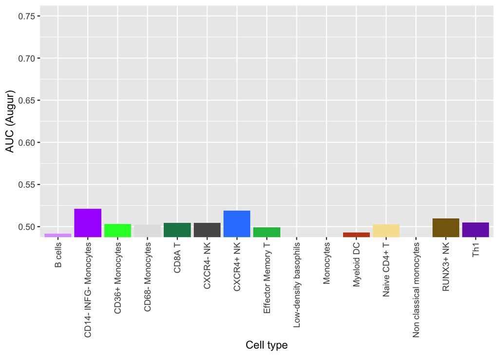

```r
library(ggplot2)

#prepare colors
library(Polychrome)
alfa <- alphabet.colors(15)

#plot
df <- as.data.frame(augur_rand1$AUC)
p <- ggplot(data=df, aes(x=cell_type, y = auc)) + geom_bar(stat = "identity", fill = alfa)
p <- p + xlab("Cell type") + ylab("AUC (Augur)") + coord_cartesian(ylim=c(0.5,0.75))
p <- p + theme(axis.text.x=element_text(angle=90,hjust=1,vjust=0.5))
plot(p)
```

```r
#save the plot
#png(file = "/Users/phillipnicol/Desktop/local_files/data/scDiffPopDATA/Augur/auc_pbmc.png")
```

## Shuffling responders and non-responders

First we reload the data to clean things up

```r
Sco <- readRDS("/Users/phillipnicol/Desktop/local_files/data/scDiffPopDATA/gse145281/seurat.RDS")
Sco <- subset(Sco, idents = c(15, 16), invert = TRUE)
```

Let’s see what types we have

```r
names(Sco@meta.data)
```

```
## [1] "orig.ident"      "nCount_RNA"      "nFeature_RNA"    "patient"
## [5] "response"        "RNA_snn_res.0.5" "seurat_clusters"
```

```r
unique(Sco@meta.data$patient)
```

```
##  [1] "R1"  "R2"  "R3"  "R4"  "R5"  "NR1" "NR2" "NR3" "NR4" "NR5"
```

Great

```r
patients <- c("R1", "R2", "R3", "R4", "R5", "NR1", "NR2", "NR3", "NR4", "NR5")
patients_perm <- sample(patients, 10, replace = FALSE)
patients_perm
```

```
##  [1] "NR4" "R4"  "NR2" "R1"  "R2"  "R5"  "R3"  "NR5" "NR1" "NR3"
```

Let’s input these in

```r
head(Sco@meta.data$patient)
```

```
## [1] "R1" "R1" "R1" "R1" "R1" "R1"
```

```r
Sco_copy <- Sco

cntr <- 1
for(i in patients) {
  row_ixs <- which(Sco_copy@meta.data$patient == i)
  Sco@meta.data$patient[row_ixs] <- patients_perm[cntr]

  strtype <- strsplit(patients_perm[cntr], split = "R")
  if(strtype[[1]][1] == "N") {
    Sco@meta.data$response[row_ixs] <- 0
  }
  else {
    Sco@meta.data$response[row_ixs] <- 1
  }

  cntr <- cntr+1
}
rm(Sco_copy)

head(Sco@meta.data$patient)
```

```
## [1] "NR4" "NR4" "NR4" "NR4" "NR4" "NR4"
```

Now we can reset responses

```r
Sco@meta.data <- data.frame(label = Sco$response, cell_type = as.integer(Sco$seurat_clusters))
Sco@meta.data[,1] <- sapply(Sco@meta.data[,1], function(x) response[x+1])
Sco@meta.data[,2] <- sapply(Sco@meta.data[,2], function(x) cell_types[x])

head(Sco@meta.data)
```

```
##                label         cell_type
## R1_HITS1432301    NR Effector Memory T
## R1_HITS1432302    NR        Myeloid DC
## R1_HITS1432303    NR Effector Memory T
## R1_HITS1432304    NR Effector Memory T
## R1_HITS1432305    NR        Myeloid DC
## R1_HITS1432306    NR   CD36+ Monocytes
```

Now we can run `Augur`

```r
augur_rand2 = Augur::calculate_auc(Sco, n_threads = 8)

save(augur_rand2, file = "/Users/phillipnicol/Desktop/local_files/data/scDiffPopDATA/Augur/augur_rand2_res.RData")
```

Load the data back up

```r
load("/Users/phillipnicol/Desktop/local_files/data/scDiffPopDATA/Augur/augur_rand2_res.RData")
```

Now we take a look at the AUC

```r
augur_rand2$AUC
```

```
## # A tibble: 14 x 2
##    cell_type                 auc
##    <chr>                   <dbl>
##  1 B cells                 0.723
##  2 RUNX3+ NK               0.667
##  3 CD14- INFG- Monocytes   0.609
##  4 CD68- Monocytes         0.603
##  5 CD36+ Monocytes         0.594
##  6 Myeloid DC              0.588
##  7 CXCR4+ NK               0.587
##  8 Effector Memory T       0.579
##  9 Non classical monocytes 0.572
## 10 CD8A T                  0.571
## 11 Naive CD4+ T            0.570
## 12 Monocytes               0.570
## 13 CXCR4- NK               0.561
## 14 Th1                     0.517
```

Note that the algorithm cut out low-density basophils, since there are only 14 responding cells which have this cell type and the default settings of their algorithm requires at least $20$ cells in each class (maybe this is interesting). Let’s also plot it

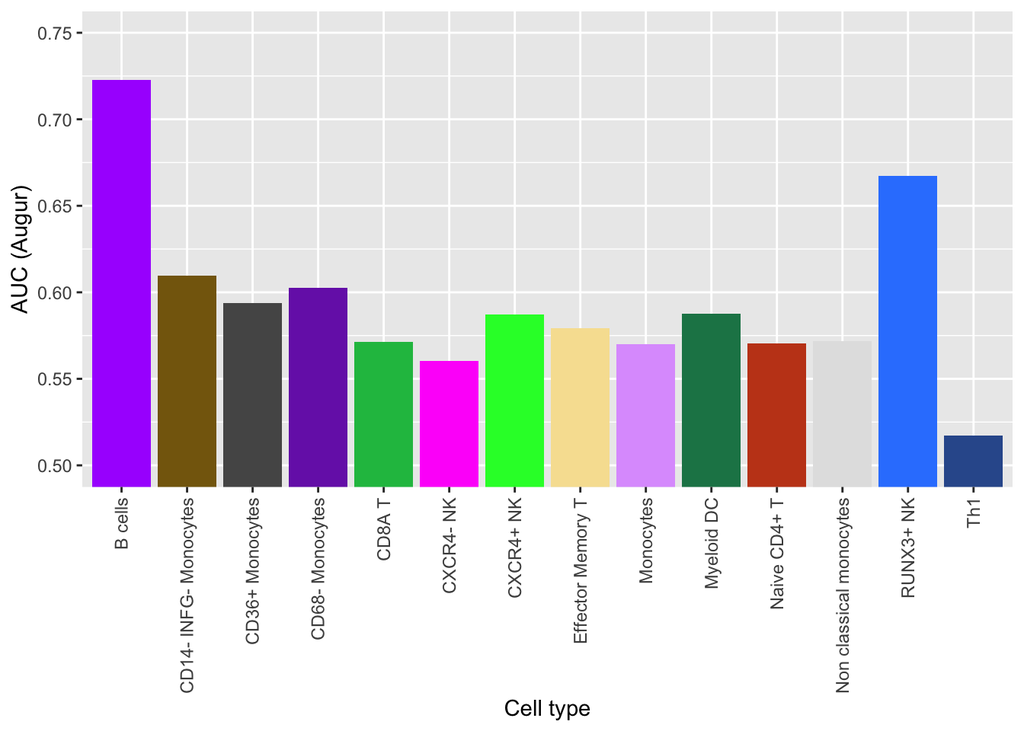

```r
library(ggplot2)

#prepare colors
library(Polychrome)
alfa <- alphabet.colors(14)

#plot
df <- as.data.frame(augur_rand2$AUC)
p <- ggplot(data=df, aes(x=cell_type, y = auc)) + geom_bar(stat = "identity", fill = alfa)
p <- p + xlab("Cell type") + ylab("AUC (Augur)") + coord_cartesian(ylim=c(0.5,0.75))
p <- p + theme(axis.text.x=element_text(angle=90,hjust=1,vjust=0.5))
plot(p)
```

```r
#save the plot
#png(file = "/Users/phillipnicol/Desktop/local_files/data/scDiffPopDATA/Augur/auc_pbmc.png")
```